# Analysis of LIHTC data for NCHFA

Zeydy Ortiz, Ph. D @ DataCrunch Lab

March 4, 2018

# Is Affordable Housing affecting Property Values?

The North Carolina Housing Finance Agency (NCHFA) works to create affordable housing opportunities for North Carolinians whose needs are not met by the market. They manage the allocation of federal Low-Income Housing Tax Credits (LIHTC) awarded to rental housing partners that agree to keep rents affordable for a period of 15 to 30 years. They wanted to understand the impact that the program may be having in the community.

Research from the ASU Stardust Center [ [Ahrentzen 2008](https://s3-us-west-2.amazonaws.com/gios-web-img-docs/docs/stardust/housing-research-synthesis/research-brief.pdf) ] identified some factors that are most often associated with impact of affordable housing on property values. One of those factors are the **“host neighborhood context.”** In particular, they found:

> “Affordable housing seems least likely to generate negative property value impacts when it is embedded within higher value, low-poverty, stable neighborhoods and when the affordable housing development is well managed.”

We partnered with NCHFA to understand the effect that affordable housing may have in property values. Using the data they have collected, I analyzed the long term (20 years) change in property values for neighborhoods in Charlotte. I compared the change for neighborhoods that host affordable housing projects through the LIHTC program versus those that do not. All neighborhoods have risen in value in 20 years - some more than others. However, the analysis shows that there is **no evidence** that hosting an affordable housing project in a neighborhood significantly affects the value of the neighborhood.

## About this project

The project was done as part of the NC OpenPass DataJam jointly organized by NC Data4Good.

**Dataset:** NCHFA provided a dataset that consisted of:

- Zillow Neighborhood property values: Month-by-month estimate of the median property values of properties in the Neighborhood from April 1996 to December 2017.
- LIHTC Indicator: Shows whether a Neighborhood received LIHTC at any time from April 1996 to December 2017.

In addition, the dataset includes a table of the number of LIHTC Properties in each of the Neighborhoods per month. We used this table to confirm that none of the properties in Charlotte had received LIHTC at the beginning of the study period.

**Neighborhood:** The Neighborhood definitions are extracted from Zillow. The dataset includes 132 Neighborhoods in Charlotte, 18 in Raleigh, and 28 in Winston-Salem.

**Goal of analysis:** Determine if there is a significant difference between the change in property value for Neighborhoods that received LIHTC and those that did not.

**Scope:** Neighborhoods in Charlotte

**Study period:** August 1997 to August 2017

## Property Values for all Charlotte Neighborhoods

The main goal is to compare Neighborhoods that received LIHTC and those that did not. Since research suggest that the the property value of the Neighborhood may be a factor, I divided the Neighborhoods into 4 distinct groups: A, B, C, and D. Each group had the same number of Neighborhoods. They were divided by the median property value in August 1997. At that time, none of the Neighborhoods had properties with LIHTC.

To evaluate the effect of LIHTC by neighborhoods, we divided them into four equal groups by the median property value in August 1997 as follows:

| Group | Property Values | Number of Neighborhoods |
| --- | --- | --- |
| A | 50,100 - 80,900 | 33 |
| B | 81,200 - 102,900 | 33 |
| C | 105,900 - 158,900 | 33 |
| D | 160,100 - 493,200 | 33 |

The interactive chart below shows the median property value for each of the neighborhoods starting with the median value in August 1997 and ending with the median value in August 2017. Hover over the points to get the value. Also, zoom in to an area to see all neighborhoods in a group.

[figure not shown]

## Comparing Change in Property Value for all Charlotte Neighborhoods

As illustrated, all neighborhoods increased in value in the 20 year span. The figure below illustrates the change for each of the groups in aggregate.

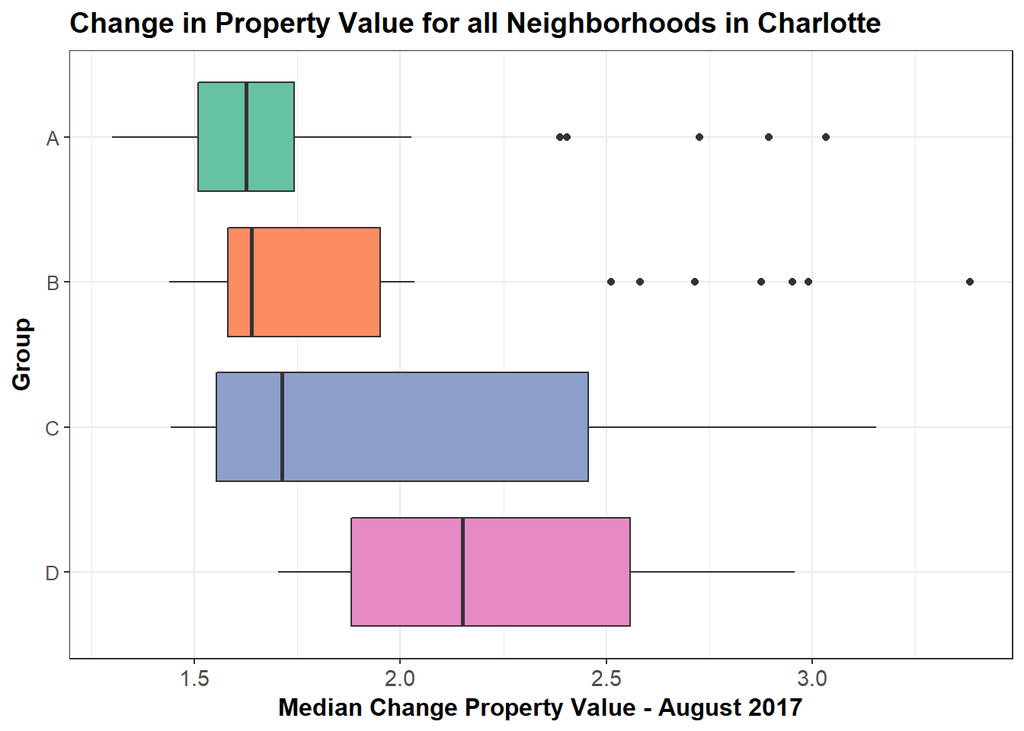

Now, each group of neighborhoods had different number of neighborhoods that received LIHTC:

| Group | Did not receive LIHTC | Received LIHTC |
| --- | --- | --- |
| A | 21 | 12 |
| B | 27 | 6 |
| C | 26 | 7 |
| D | 30 | 3 |

We calculated the simple change in value in the 20 years from August 1997 to August 2017. The table below shows that all neighborhods grew in value, some more than others.

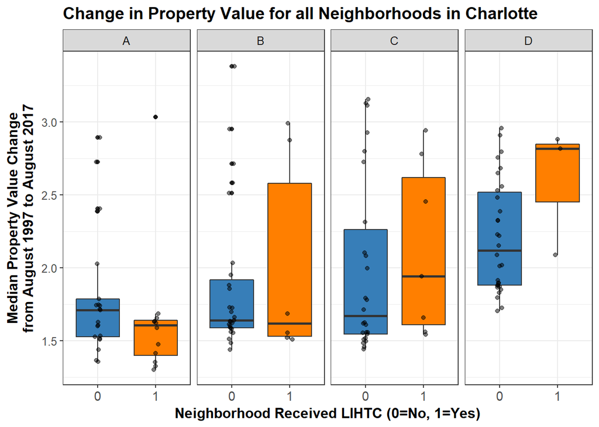

## Statistical Analysis

When looking at neighborhoods that received LIHTC compared to those that did not receive it, the t-test indicates that we can’t conclude that there is a significant difference between the change that those neighborhoods experience in the last 20 years (high p-value). The results of the statistical test are:

Group A:

```
##
##  Welch Two Sample t-test
##
## data:  x and y
## t = 1.3999, df = 27.04, p-value = 0.1729
## alternative hypothesis: true difference in means is not equal to 0
## 95 percent confidence interval:
##  -0.1208632  0.6400366
## sample estimates:
## mean of x mean of y
##  2.029800  1.770214
```

Group B:

```
##
##  Welch Two Sample t-test
##
## data:  x and y
## t = -0.62138, df = 5.7656, p-value = 0.5581
## alternative hypothesis: true difference in means is not equal to 0
## 95 percent confidence interval:
##  -0.9450216  0.5652683
## sample estimates:
## mean of x mean of y
##  1.864650  2.054527
```

Group C:

```
##
##  Welch Two Sample t-test
##
## data:  x and y
## t = -0.61405, df = 9.4783, p-value = 0.5536
## alternative hypothesis: true difference in means is not equal to 0
## 95 percent confidence interval:
##  -0.7183185  0.4097526
## sample estimates:
## mean of x mean of y
##  2.015178  2.169461
```

Group D:

```
##
##  Welch Two Sample t-test
##
## data:  x and y
## t = -1.4294, df = 2.2537, p-value = 0.2758
## alternative hypothesis: true difference in means is not equal to 0
## 95 percent confidence interval:
##  -1.4921590  0.6872667
## sample estimates:
## mean of x mean of y
##  2.214613  2.617059
```

## Property Values for all Neighborhoods in the Dataset

The neighborhoods per group:

[output not shown]

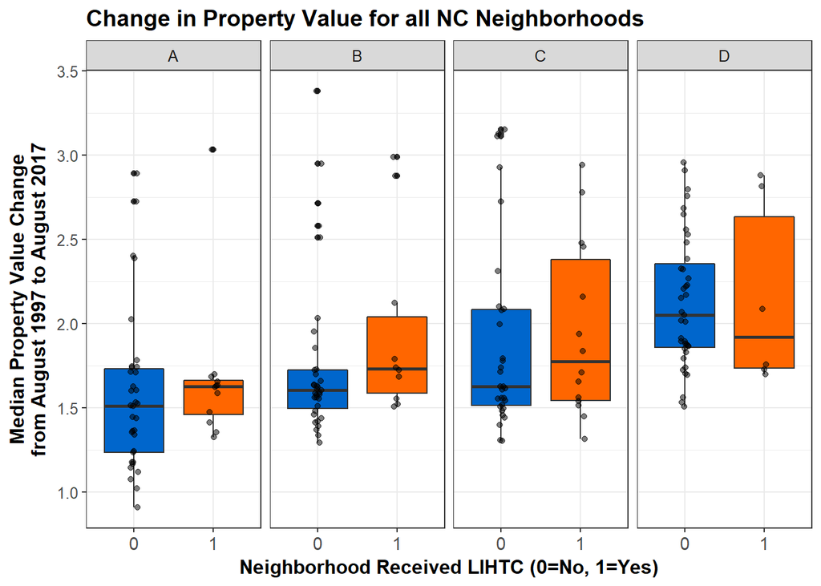

Group A:

```
##
##  Welch Two Sample t-test
##
## data:  x and y
## t = -0.56202, df = 25.978, p-value = 0.5789
## alternative hypothesis: true difference in means is not equal to 0
## 95 percent confidence interval:
##  -0.4464251  0.2547260
## sample estimates:
## mean of x mean of y
##  1.706234  1.802083
```

Group B:

```
##
##  Welch Two Sample t-test
##
## data:  x and y
## t = -1.3419, df = 12.099, p-value = 0.2043
## alternative hypothesis: true difference in means is not equal to 0
## 95 percent confidence interval:
##  -0.6657034  0.1579711
## sample estimates:
## mean of x mean of y
##  1.741326  1.995192
```

Group C:

```
##
##  Welch Two Sample t-test
##
## data:  x and y
## t = -0.43747, df = 25.904, p-value = 0.6654
## alternative hypothesis: true difference in means is not equal to 0
## 95 percent confidence interval:
##  -0.4268694  0.2770784
## sample estimates:
## mean of x mean of y
##  1.903936  1.978832
```

Group D:

```
##
##  Welch Two Sample t-test
##
## data:  x and y
## t = -0.11603, df = 5.6815, p-value = 0.9116
## alternative hypothesis: true difference in means is not equal to 0
## 95 percent confidence interval:
##  -0.6250125  0.5691531
## sample estimates:
## mean of x mean of y
##  2.145966  2.173896
```

### Concluding Remarks

The analysis shows that there is no evidence of a long term effect due to LIHTC for Neighborhoods when comparing Neighborhoods with similar property values. We suggest additional analysis to be done for shorter time frames as well as grouping the Neighborhoods using other demographic characteristics.